# Part II - [Airline On-Time Performance Data](https://community.amstat.org/jointscsg-section/dataexpo/dataexpo2009)

## by Odai Alsalieti

## Investigation Overview

> I am more interested in researching delayed and canceled flights and researching their causes

## Dataset Overview

> This database contains scheduled and actual departure and arrival times reported by certified U.S. air carriers that account for at least one percent of domestic scheduled passenger revenues. The data is collected by the Office of Airline Information, Bureau of Transportation Statistics (BTS).  
> The extracted data for last 3 years(2006-2007-2008) contains 6060809 rows × 29 columns that are described [here](https://www.transtats.bts.gov/DatabaseInfo.asp?QO_VQ=EFD&Yv0x=D) in detail

## Carrier had the most delays and cancellation flights:

> **Southwest Airlines** , **American Airlines** and **Envoy Air**: had the most delays and cancellation over mean by Carrier in **2008**, **2007**, **2006**

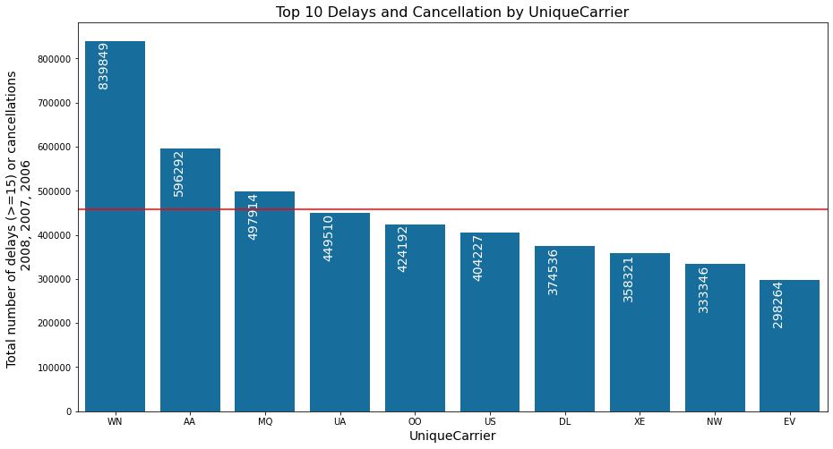

## Airoport had the Most Delay and cancellation flights:

> **Chicago O'Hare International Airport (ORD)** , **Atlanta Airport (ATL)** and **Dallas/Ft Worth Intl(DFW)**: had the most delays and cancellation over mean by Origin in **2008, 2007, 2006**

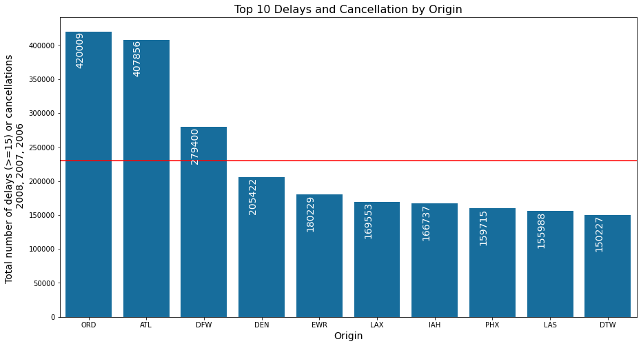

## Month had the most Delays and Cancellation flights:

> **December** had the most delays and cancellation over mean in **2008, 2007, 2006**

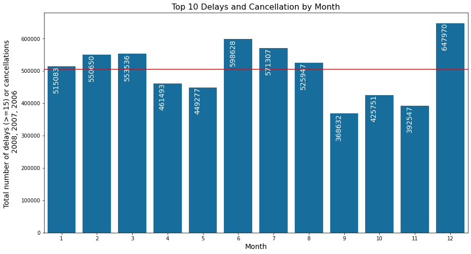

## DayofWeek that had most Delays and Cancellation flights:

> **Friday** had the most delays and cancellation over mean in **2008, 2007, 2006**

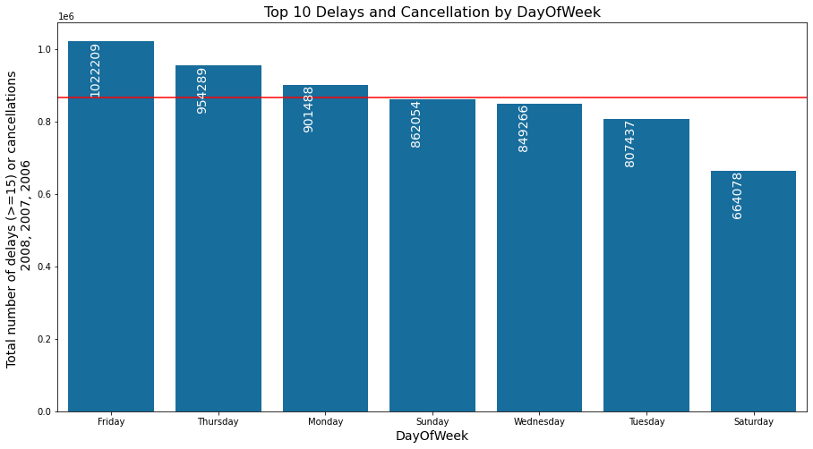

## Most cancellation reasons:

> Cancellation by Carrier and National Aviation System are the top two reasons for cancellations over mean

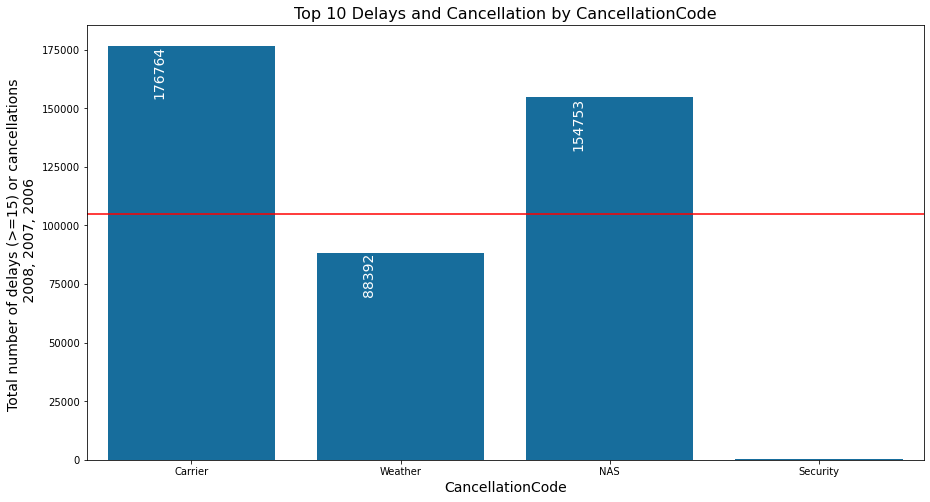

## Plans had most Delays and Cancellation by Tail Number:

> Plans with tail numbers : **N17175**, **N651ML**, **N715SF**, had the most delays and cancellation

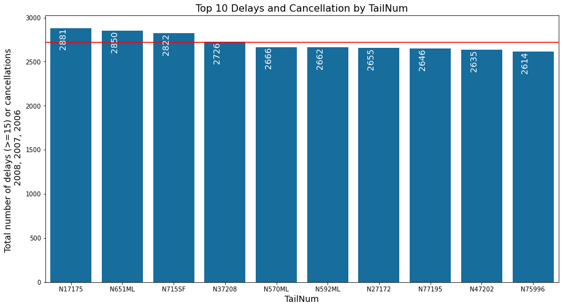

## Departure Delays by day of Month:

> 23th December had the highest Average of Departure delays

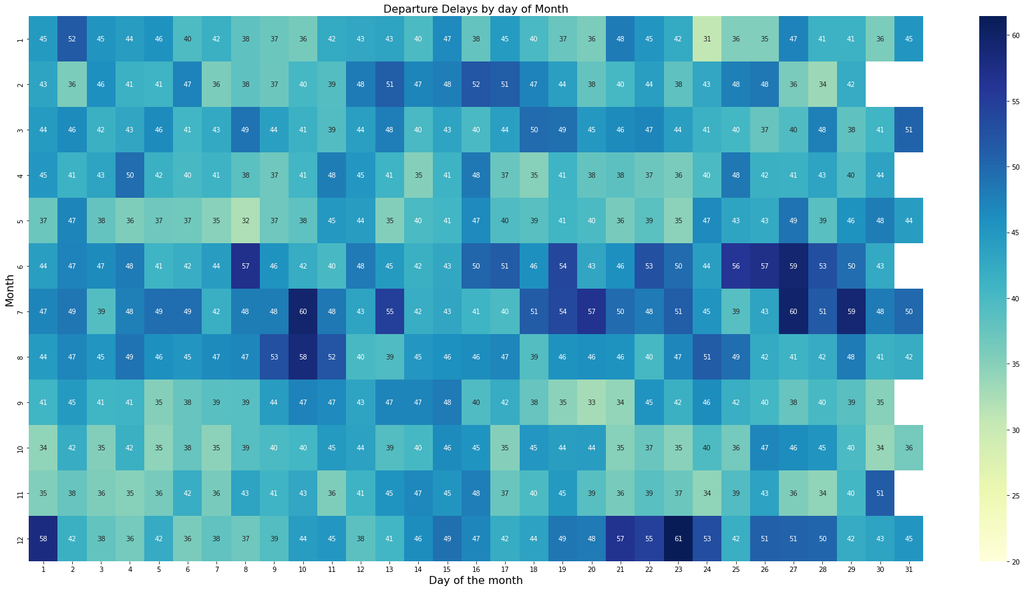

## Departure Delays by day of Week:

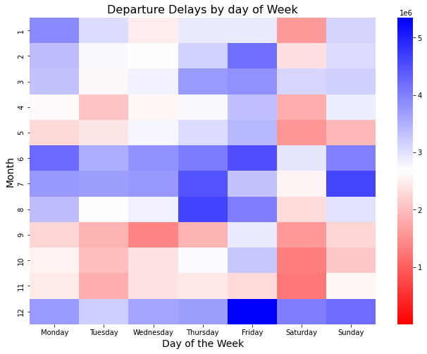

## Departure Cancelled by day of Month:

> 12th, 13th, 14th February had the most Cancelled flights

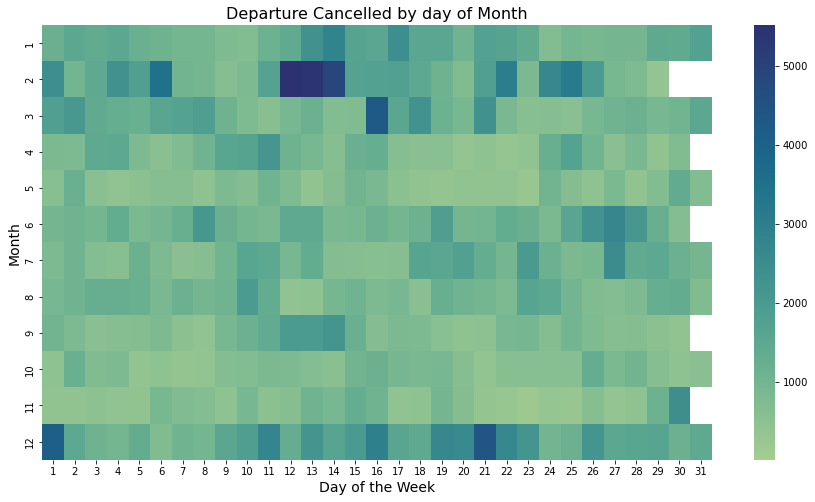